Theobio main page

# Ontario COVID-19 forecasts

[#MacTheobio COVID Modelling Group](https://mac-theobio.github.io/covid-19/)

Irena Papst ([@irenapapst](https://twitter.com/irenapapst)), Ben Bolker ([@bolkerb](https://twitter.com/bolkerb)), Jonathan Dushoff ([@jd_mathbio](https://twitter.com/jd_mathbio)), David Earn ([@DavidJDEarn](https://twitter.com/davidjdearn))

McMaster University, Hamilton, Ontario, Canada, L8S 4K1

Forecast date: 26 Nov 2021

*Post last updated: 7 Dec 2021*

# Context

Every three weeks, [our group](https://mac-theobio.github.io/covid-19/) provides COVID-19 infection report forecasts for the province of Ontario to the [Ontario Modelling Consensus Table](https://covid19-sciencetable.ca/our-partners/) (MCT), a partner of the [Ontario Science Advisory Table](https://covid19-sciencetable.ca) (SAT), which presents this information to the Health Coordination Table of the Ontario Ministry of Health.[^1] Other modelling groups also provide forecasts to the MCT. After reviewing all forecasts provided, the MCT provides consensus projections to the SAT.

Our forecasts are based on a [compartmental epidemic model](https://en.wikipedia.org/wiki/Compartmental_models_in_epidemiology) implemented in our publicly available [`McMasterPandemic`](https://github.com/bbolker/McMasterPandemic) R package, and involve statistical fits to [Ontario’s latest infection report data](https://covid-19.ontario.ca/data).

# Forecast overview

The forecast presented here was made on **26 Nov 2021** and was submitted to the MCT for inclusion in the SAT’s [update on COVID-19 projections](https://covid19-sciencetable.ca/sciencebrief/update-on-covid-19-projections-14/), released on 7 Dec 2021.

This set of projections is meant to **evaluate the current situation in the province** as we continue to cautiously reopen. We describe the transmission scenarios we considered in detail below.

**This set of forecasts does not account for any effect of the Omicron variant**, first detected in the province on [28 Nov](https://news.ontario.ca/en/statement/1001241/ontario-confirms-first-two-cases-of-omicron-variant). On the forecast date of 26 Nov, it was not yet known with any certainty whether this strain is more infective than Ontario’s resident strain, Delta, or if Omicron may evade some of the protection conferred by past infection or vaccination. When we know more about Omicron’s properties and early prevalence in Ontario, we will incorporate the invasion of this variant explicitly into our projections.

We have updated, and will continue to update, this post in order to show the [latest infection reports](https://covid-19.ontario.ca/data), but the forecasts themselves have not, and will not, be modified after the forecast date.

# Forecast results

The following figure gives the infection report forecasts (curves), with 95% confidence intervals as bands around each forecast curve. Observed infection reports to which the model was fit are plotted with **solid points**, while observations after the fact are included as **hollow points**.

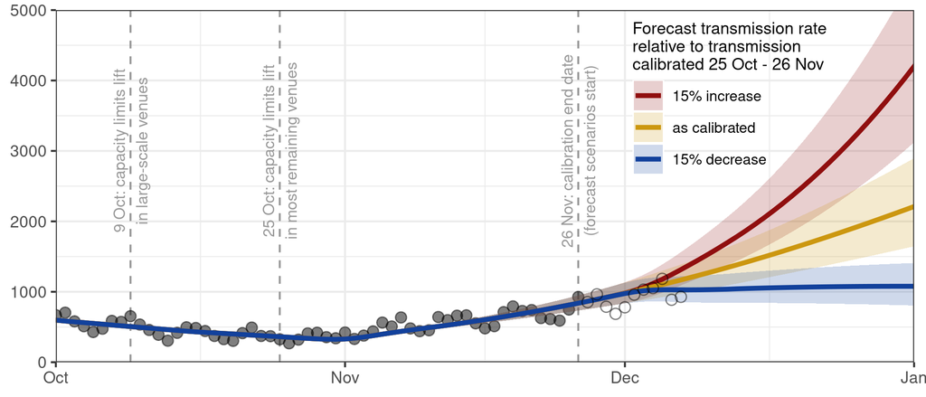

Infection reports have been rising slowly in the province since early November, and without any changes to the current situation, we anticipate that they will continue rising through December (the as calibrated scenario).

If transmission were to increase further, as in the 15% increase scenario, the situation may worsen. Transmission could increase if individuals gather indoors more frequently and/or in larger groups (as may happen over the holiday season), especially without taking precautions such as getting vaccinated, encouraging ventilation through indoor spaces, and masking. Transmission may also increase if Omicron turns out to be more infective than the Delta variant.

On the other hand, transmission could decrease, as in the 15% decrease scenario, for a variety of reasons. Individuals may continue to take precautions to limit spread. Schools are slated to close for the winter break in mid-December, which is likely to interrupt some chains of transmission: [recently, the under 20 age group has been representing the largest number of active reported cases](https://covid-19.ontario.ca/data/case-numbers-and-spread) in the province. For instance, on 6 Dec, 32% of all active cases were in the under 20 age group, even though it represents only 21% of the provincial population, based on the [latest population estimates from Statistics Canada](https://www150.statcan.gc.ca/t1/tbl1/en/tv.action?pid=1710000501&pickMembers%5B0%5D=1.7&pickMembers%5B1%5D=2.1&cubeTimeFrame.startYear=2021&cubeTimeFrame.endYear=2021&referencePeriods=20210101%2C20210101). Children aged 5-11 [began receiving their first doses of the pediatric COVID-19 vaccine](https://news.ontario.ca/en/release/1001195/covid-19-vaccine-bookings-to-open-for-all-children-aged-five-to-11) the week of 22 Nov, and while our simulations assume vaccination continues at its current pace (resulting in about 30% of 5-11 year olds with a first dose by the end of December), this pace may accelerate, which could also help decrease transmission.

Trends in transmission will be influenced some combination of the above effects, and possibly other effects we have neglected to mention here; **it is not yet clear what the net effect will be on transmission** though December and onward.

# Forecast and model details

## Transmission

We assume that **the transmission rate is piecewise constant** through the fit (calibration) period, selecting re-estimation dates for this rate based on large-scale changes in public health measures (*e.g.* a stay-at-home order or a major reopening step) or when it appears individual behaviour may be changing. By assuming that the transmission rate is constant between re-estimation dates, we capture the average effect of any changes in transmission over the entire period between these dates.

Our forecast scenarios focus on examining the current situation in the province. We consider **three scenarios** for a change in the transmission rate on 26 Nov (the **calibration end date** and **forecast scenario start date**) to a new constant rate. The new forecast transmission rate in each scenario is expressed as a percentage of the most-recently fitted transmission rate (calibrated over the last four weeks of data at the time of forecast, specifically 25 Oct - 26 Nov):

1. as calibrated, *i.e.* a status quo forecast;
2. a 15% increase in transmission;
3. a 15% decrease in transmission.

We chose to base our forecast scenarios on the transmission rate estimated between 25 Oct and the forecast date since 25 Oct is the date of the most recent major reopening step, where [the provincial government lifted capacity limits in most remaining venues requiring proof of vaccination](https://news.ontario.ca/en/release/1001027/ontario-releases-plan-to-safely-reopen-ontario-and-manage-covid-19-for-the-long-term). We assume this action represents the last major change to transmission in the province before the forecast date, and so the transmission rate calibrated after this change represents the current status quo. (We did not consider any additional public health measures in the forecast period, though [some Public Health Units began reintroducing some measures as early as 26 Nov](https://globalnews.ca/news/8405568/some-ontario-health-units-reintroduce-covid-restrictions/) in response to high local daily case counts.)

Due to the delay in infection reports, differences among the forecast scenarios in the plot above do not become apparent until about two weeks after the forecast scenario start date (*i.e.*, the projections begin diverging significantly around 10 Dec).

## Variants

Virtually all infections in the province have been caused by **Delta since early August** (see Figure 5 in the [Public Health Ontario Daily Epidemiologic Report](https://www.publichealthontario.ca/-/media/documents/ncov/epi/covid-19-daily-epi-summary-report.pdf?sc_lang=en)). We model the takeover of Alpha by Delta through the spring and summer of 2021 since the per-dose infection-blocking vaccine efficacy differs significantly between the two strains (see Vaccination for more details). In doing so, we assume that Delta is **50% more infective** than Alpha and use data on variant surveillance from Public Health Ontario to specify the variant takeover model.

**Our forecasts do not yet account for any effect of the new Omicron variant**, as it has not yet been established how this strain differs from Delta, and what effect these differences may have on the epidemiology of COVID-19 in Ontario. If Omicron becomes established in Ontario in the coming weeks, and changes the local epidemiology significantly, we will incorporate its effect into our future projections.

## Vaccination

For vaccination, we use the reported number of first and second doses administered each day in the fit period.

For our projections, we assume that it takes a few months for **first doses** to saturate to **92%** of the eligible population (aged 5+ in 2021) and for **second doses** to saturate to **90%**. For comparison, as of the forecast date of 26 Nov 2021:

- **82%** of Ontarians **5+** had received at least one dose, while **80%** had received two doses,
- **90%** of Ontarians **12+** had received at least one dose, while **87%** had received two doses,

according to data provided by [COVID-19 Tracker Canada](https://covid19tracker.ca/provincevac.html?p=ON).

We anticipate vaccine coverage to continue rising steadily in the coming months as [newly eligible children aged 5-11](https://news.ontario.ca/en/release/1001195/covid-19-vaccine-bookings-to-open-for-all-children-aged-five-to-11) are vaccinated. Our current assumptions on vaccination through the forecast period imply first dose coverage of **about 30%** in children aged 5-11 by the end of December.

**We do not currently incorporate third doses in our model** as these have been administered to only 5% of the entire Ontario population as of 5 Dec. We will incorporate this effect when third doses become more widespread, as anticipated after [the National Advisory Committee on Immunization’s (NACI) latest recommendations on COVID-19 immunizations](https://www.canada.ca/content/dam/phac-aspc/documents/services/immunization/national-advisory-committee-on-immunization-naci/guidance-booster-covid-19-vaccine-doses/summary.pdf), where they state:

- NACI strongly recommends a booster dose of an authorized mRNA COVID-19 vaccine should be offered at least 6 months after completion of a primary COVID- 19 vaccine series to the following groups:
  - People aged 50 years and older
  - Adults living in long-term care homes for seniors or other congregate living settings that provide care for seniors
  - Recipients of a viral vector vaccine series completed with only viral vector vaccines (AstraZeneca/COVISHIELD or Janssen COVID-19 vaccine)
  - Adults in or from First Nations, Inuit and Métis communities
  - All frontline healthcare workers having direct in-person contact with patients
- NACI now also recommends that a booster dose of an authorized mRNA COVID-19 vaccine may be offered to adults 18 to 49 years of age at least 6 months after completion of a primary COVID-19 vaccine series with consideration of jurisdictional and individual risks as outlined in [the full NACI Statement](https://www.canada.ca/content/dam/phac-aspc/documents/services/immunization/national-advisory-committee-on-immunization-naci/guidance-booster-covid-19-vaccine-doses/guidance-booster-covid-19-vaccine-doses.pdf)

**Per-dose infection-blocking vaccine effectivenesses** differs between Alpha and Delta, so we adjust them in the model depending on the daily estimated frequency of the Delta variant. The baseline effectivenesses used are:

|  | First dose | Second dose |
| --- | --- | --- |
| Alpha | 60% | 90% |
| Delta | 30% | 80% |

The vaccination model also includes the following assumptions:

1. **Vaccine-derived immunity** takes an average of **14 days** to develop after a dose is administered.
2. If a vaccinated individual is infected, their **probability of having a less-transmissible, asymptomatic infection** increases with each dose (20% for the unvaccinated, 60% for those protected by one dose, and 90% for those protected by two doses).
3. Vaccines are administered **at random** in the population (we do not explicitly account for age or other characteristics of individuals).

Related post: [Ontario COVID-19 forecasts, 17 Oct 2021](https://mac-theobio.github.io/forecasts/outputs/McMasterOntarioForecastsBlog2021-10-17)

[Back to the MacTheobio COVID Modelling Group page](https://mac-theobio.github.io/covid-19/)

[^1]: This report has been written independently of the Ontario Modelling Consensus Table, the Ontario Science Advisory Table, and the Health Coordination Table. The views expressed in this report are solely the authors’.